# Cancer in the UK

Scotland overview 2024

# Cancer in Scotland

## Summary

This summary provides an overview of key metrics and data across the cancer pathway in Scotland, as part of the Cancer in the UK: Overview 2024 report, which provides the full UK picture. It looks at where progress is being made and what challenges remain in Scotland.

Overview of key cancer statistics in Scotland

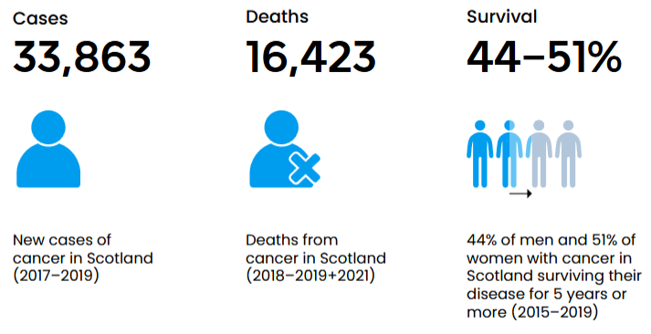

## The number of cancer cases is rising in Scotland

Every day, 93 people are diagnosed with cancer in Scotland and around 45 people die from the disease [1,2]. The number of cases is projected to rise by almost a fifth, from around 36,000 in 2023–2025 to around 42,100 new cases per year in 2038–2040 (3).

**This increase will place an unprecedented burden on an overstretched healthcare system.**

## Around 4 in 10 cancer cases in Scotland can be prevented

Smoking and overweight and obesity are the two biggest preventable causes of cancer in Scotland. They cause around 5,700 and 2,200 cases of cancer each year in Scotland, respectively (5).

Smoking levels are at their lowest recorded point – around 1 in 10 (11%) of the Scottish adult population smoke (6). But levels aren’t declining fast enough. Scotland isn’t on track to be tobacco-free (less than 5% adult smoking prevalence) by the 2034 target and isn’t due to reach this target until 2048 (7).

Meanwhile, overweight and obesity is at its highest recorded level – around two-thirds (67%) of adults are overweight or obese (6). If current trends continue, by 2040 around 3.2 million people will be overweight or obese (8).

Tackling cancer through prevention requires individuals to make changes to their lives but support from governments and health professionals is crucial to facilitate those changes. The Scottish Government has committed to bring forward legislation to restrict price promotions on food and drink high in fat, salt and sugar (HFSS), and Cancer Research UK urges this to be a top priority for the forthcoming year. This will help make the healthier choice the easier choice to make.

## Screening uptake varies between programmes

There are currently three national cancer screening programmes in Scotland, for bowel, breast and cervical cancer. Around 7% of all cancer cases in Scotland are detected through these screening programmes (9).

Around 67% of people take up their bowel cancer screening invitation (10) and 77% their breast cancer screening invitation (11). Coverage of cervical screening has been declining over the past five years and is currently at its lowest on record, around 69% (12).

In 2022, the UK National Screening Committee recommended a UK-wide targeted lung screening programme for people identified with a history of smoking, as they are at an increased risk of lung cancer. Scotland has not yet implemented a targeted lung screening programme. If implemented and uptake was to reach 50%, Cancer Research UK estimates around 420 extra patients each year across Scotland could be diagnosed at an early stage rather than a late stage (13), and that around 230 lung cancer deaths could be avoided each year through the programme (14).

NHS National Services Scotland should ensure full implementation of the Equity in Screening strategy Action Plan by 2026, to help reduce inequalities in all cancer screening programmes. The introduction of new screening programmes and improvement of current ones must be brought in on time and with a sufficient uplift in diagnostic capacity. In particular, the Scottish Government should approve the rollout of a national targeted lung screening programme in Scotland, making sure smoking cessation is an integral part of the programme.

## References

1

National Records of Scotland. [Vital events reference tables](https://www.nrscotland.gov.uk/publications/vital-events-reference-tables-2023/). 2024.

2

Cancer incidence in scotland: To december 2023. 2025. https://publichealthscotland.scot/publications/cancer-incidence-in-scotland/cancer-incidence-in-scotland-to-december-2023/.